# Algo2022 Group 7 Data Visualisation

Comparative study of PSSM, ANN, SMM for peptide MHC binding

# Dataset statistics

| Allele | Size | Number of binders |
| --- | --- | --- |
| A0101 | 1157 | 103 |
| A0201 | 3089 | 1181 |
| A0202 | 1447 | 649 |
| A0203 | 1443 | 639 |
| A0206 | 1437 | 513 |
| A0301 | 2094 | 517 |
| A1101 | 1985 | 693 |
| A2301 | 104 | 49 |
| A2402 | 197 | 99 |
| A2403 | 254 | 29 |

[output cut: 25 more lines]

```
[1] 86
```

## No. binders vs size

The number of binders clearly scales linearly with the size of the dataset.

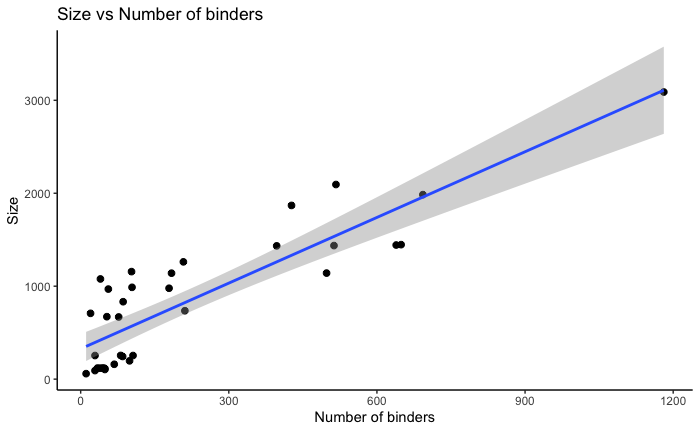

**PCC Size vs no. binders**

```
[1] 0.8714809
```

# PSSM

**Beta = 100, weighting on**

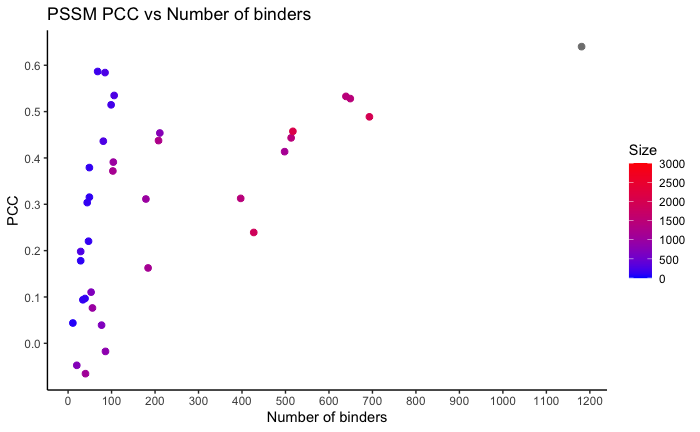

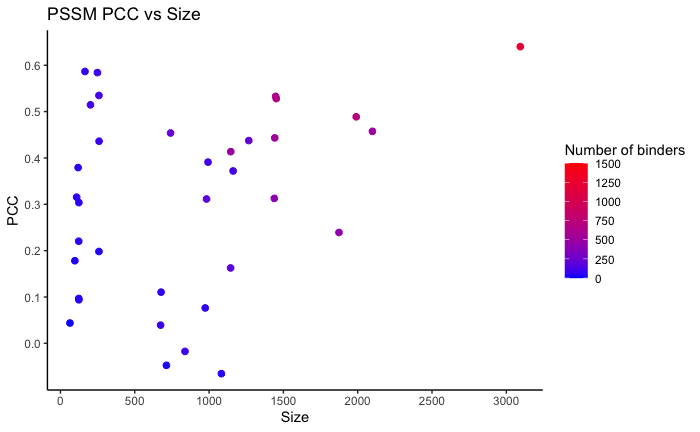

## Assessing optimal beta

From the graphs, PCC performance between beta values is minimal.

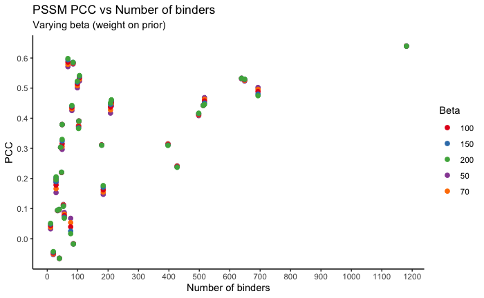

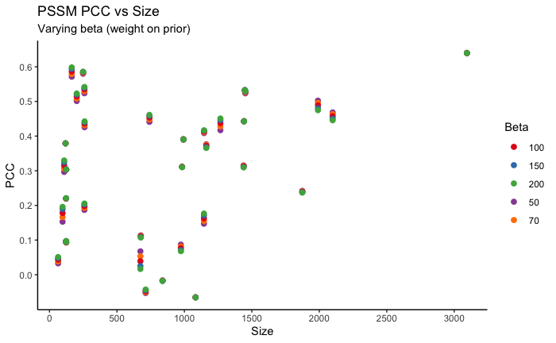

# SMM

## SMM: Gradient descent

**Lambda = 0.01, epsilon = 0.05, epochs = 100 (doesn’t make a difference).**  
*Lambda = 1 gave optimum results, so those values are used in the final comparison*

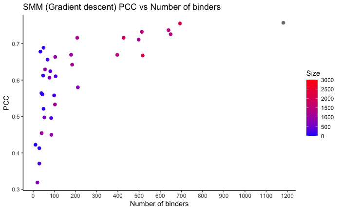

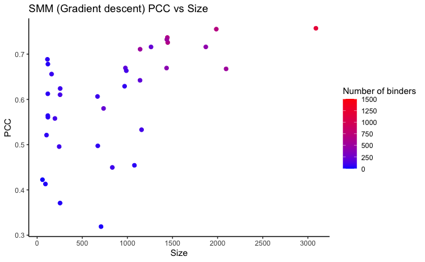

### Optimising lambda

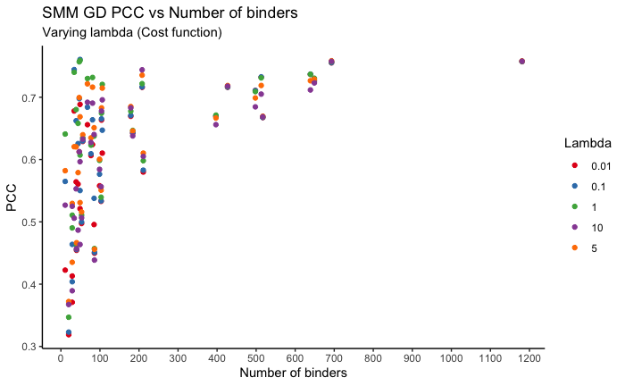

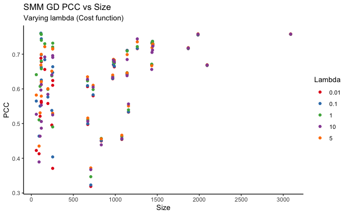

### Assessment of lambda

1 has best overall performance - by graph, and it has highest average.

| Lambda = 0.01 mean PCC |
| --- |
| 0.600164 |

| Lambda = 0.1 mean PCC |
| --- |
| 0.6239389 |

| Lambda = 1 mean PCC |
| --- |
| 0.6467337 |

| Lambda = 5 mean PCC |
| --- |
| 0.6317323 |

| Lambda = 10 mean PCC |
| --- |
| 0.6079743 |

## SMM: Monte Carlo

**Lambda = 0.01, Epochs = 1000 ; no optimisations made**

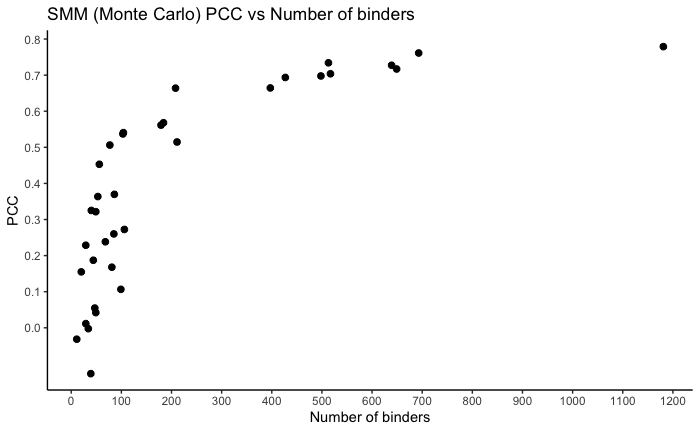

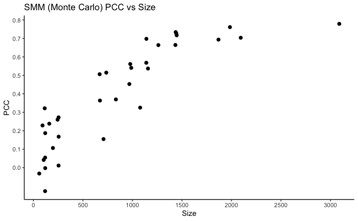

# ANN

**Originally run with BLOSUM encoding - sparse coding was later found to be inferior, so the final comparisons are used with BLOSUM encoding**

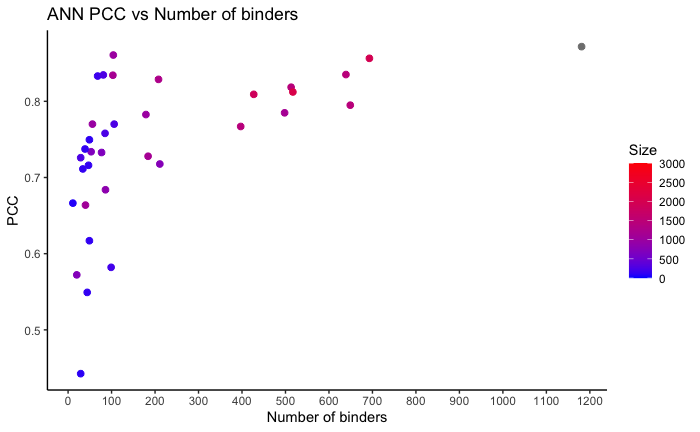

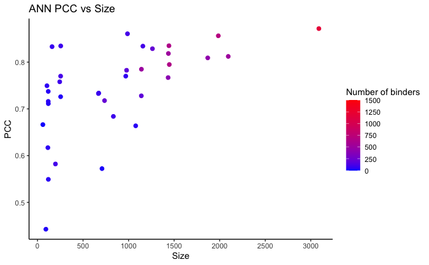

## BLOSUM vs Sparse encoding

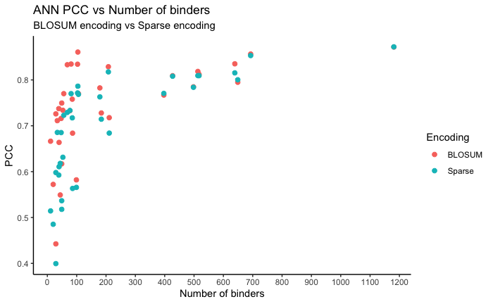

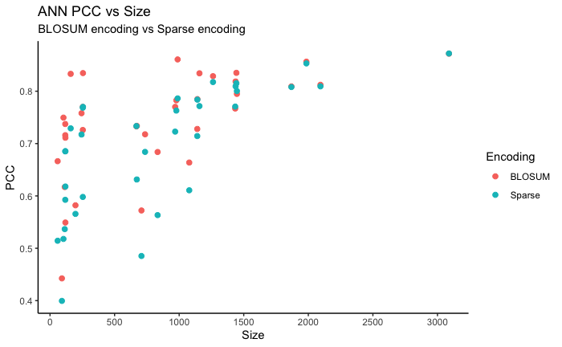

```r
ANN_original %>% select(PCC) %>% summarise(`BLOSUM mean PCC` = mean(PCC)) %>% round(3)
```

| BLOSUM mean PCC |
| --- |
| 0.741 |

```r
ANN_sparse %>% select(PCC) %>% summarise(`sparse mean PCC` = mean(PCC)) %>% round(3)
```

| sparse mean PCC |
| --- |
| 0.694 |

# Comparing all results

**ALL results are compared using the optimal parameters.**

**PSSM: beta = 100** - beta had no significant on performance, so we just use the original beta value  
**SMM GD: lambda = 1, epsilon = 0.05, epochs = 100** - optimised, from lambda 0.01 originally  
**SMM MC: lambda = 0.01, epochs = 1000**  
**ANN: BLOSUM encoding**

## Average PCC

| PSSM mean PCC | GD mean PCC | MC mean PCC | ANN mean PCC |
| --- | --- | --- | --- |
| 0.308 | 0.647 | 0.393 | 0.741 |

## Max PCC

| PSSM max PCC | GD max PCC | MC max PCC | ANN max PCC |
| --- | --- | --- | --- |
| 0.64 | 0.759 | 0.779 | 0.872 |

## Negative PCC values

3 negative values in PSSM and MC.  
Interestingly enough, there are 3 different allele in each case.

**PSSM**

[output not shown]

**MC**

| Allele | Size | PCC | Number of binders |
| --- | --- | --- | --- |
| B4002 | 118 | -0.12707 | 39 |
| B4403 | 119 | -0.00242 | 34 |
| B5701 | 59 | -0.03162 | 11 |

## Visualise performance for ALL methods

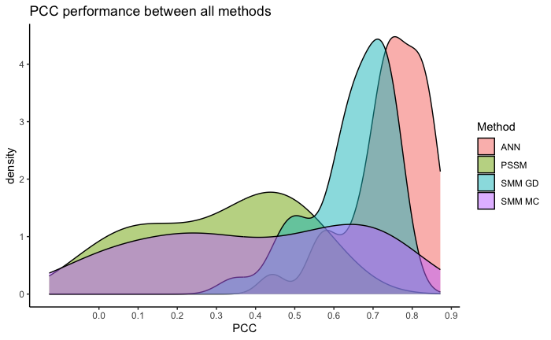

**Alternate plot (ridgeline)**

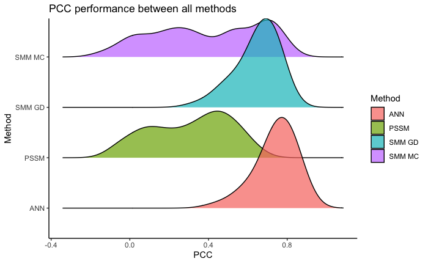

## Visualising PCC vs Size and Number of binders for all methods

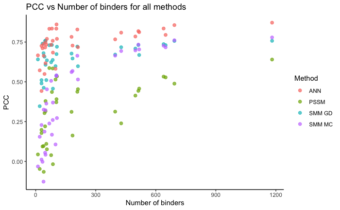

## Exploring the size categories and average performance between them

| Allele | Size | Number of binders | Category |
| --- | --- | --- | --- |
| A0101 | 1157 | 103 | Small |
| A2301 | 104 | 49 | Small |
| A2402 | 197 | 99 | Small |
| A2403 | 254 | 29 | Small |
| A2601 | 672 | 53 | Small |
| A2902 | 160 | 68 | Small |
| A3001 | 669 | 77 | Small |
| A3002 | 92 | 29 | Small |
| A3301 | 1140 | 184 | Small |
| A6901 | 833 | 86 | Small |

[output cut: 16 more lines]

| Allele | Size | Number of binders | Category |
| --- | --- | --- | --- |
| A0202 | 1447 | 649 | Medium |
| A0203 | 1443 | 639 | Medium |
| A0206 | 1437 | 513 | Medium |
| A0301 | 2094 | 517 | Medium |
| A1101 | 1985 | 693 | Medium |
| A3101 | 1869 | 427 | Medium |
| A6801 | 1141 | 498 | Medium |
| A6802 | 1434 | 397 | Medium |

| PSSM small |
| --- |
| 0.2580512 |

| PSSM medium |
| --- |
| 0.4269925 |

| SMM GD small |
| --- |
| 0.6213842 |

| SMM GD medium |
| --- |
| 0.7152375 |

| SMM MC small |
| --- |
| 0.2803358 |

| SMM MC medium |
| --- |
| 0.7124238 |

| ANN small |
| --- |
| 0.7154515 |

| ANN medium |
| --- |
| 0.80979 |